# The `adegraphics` package

## 4.3 Parameters in `g.args`

The `g.args` slot is a list of parameters specific to the function used (and thus to the class of the returned object). Several parameters are very general and used in all `adegraphics` functions:

- `xlim`, `ylim`: limits of the graph on the x and y axes
- `main`, `sub`: main title and subtitle
- `xlab`, `ylab`: labels of the x and y axes
- `scales`: a list determining how the x and y axes (tick marks dans labels) are drawn; this is the `scales` parameter of the `xyplot` function of `lattice`

The `ADEg.S2` objects can also contain spatial information (map stored as a `Spatial` object or neighborhood stored as a `nb` object):

- `Sp`, `sp.layout`: objects from the `sp` package to display spatial objects, `Sp` for maps and `sp.layout` for spatial widgets as a North arrow, scale, etc.
- `nbobject`: object of class `nb` or `listw` to display neighbor graphs.

When the `facets` (see the Partitioning the data (`facets`) section) argument is used, users can modify the parameter `samelimits`: if it is `TRUE`, all graphs have the same limits whereas limits are computed for each subgraph independently when it is `FALSE`. For example, considering the `jv73` data set, each subgraph is computed with its own limits and labels are then more scattered:

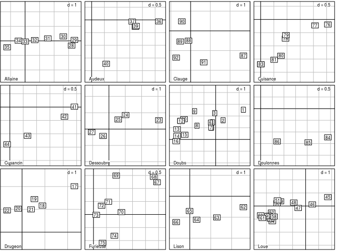

```r
s.label(pca2$li, facets = jv73$fac.riv, samelimits = FALSE)
```

## 4.4 Parameters applied on a `ADEgS`

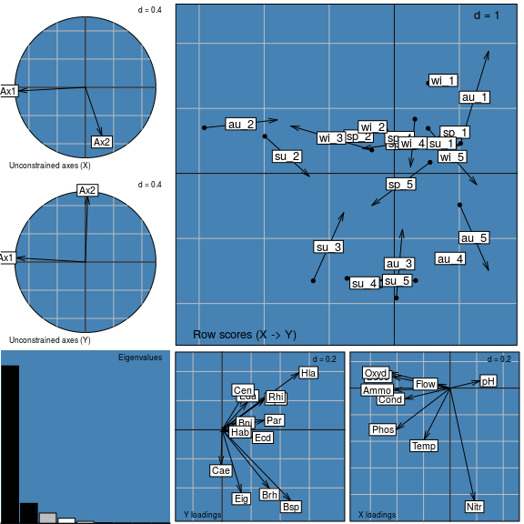

```r
g15 <- plot(coi1, pbackground.col = "steelblue")
```

To change the parameters of a given graph, the name of the parameter must be preceded by the name of the subgraph. This supposes that the names of subgraphs are known. For example, to modify only two graphs:

```r
names(g15)
```

```
## [1] "Xax"       "Yax"       "eig"       "XYmatch"   "Yloadings" "Xloadings"
```

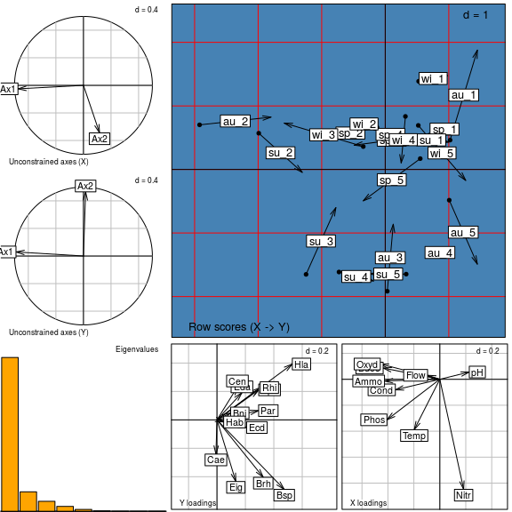

```r
plot(coi1, XYmatch.pbackground.col = "steelblue",  XYmatch.pgrid.col = "red",
     eig.ppolygons.col = "orange")
```

# 5 Using `adegraphics` functions in your package

In this section, we illustrate how `adegraphics` functionalities can be used to implement graphical functions in your own package. We created an objet of class `track` that contains a vector of distance and time.

```r
tra1 <- list()
tra1$time <- runif(300)
tra1$distance <- tra1$time * 5 + rnorm(300)
class(tra1) <- "track"
```

For an object of the class `track`, we wish to represent different components of the data:

- an histogram of distances
- an histogram of speeds (i.e., distance / time)
- a 2D plot representing the distance, the time and the line corresponding to the linear model that predict distance by time

The corresponding multiple plot can be done using `adegraphics` functions:

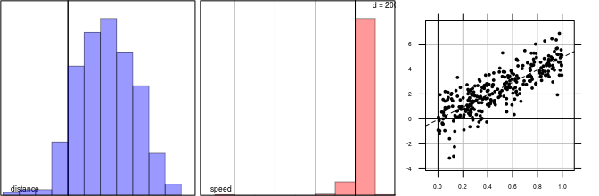

```r
g1 <- s1d.hist(tra1$distance, psub.text = "distance", ppolygons.col = "blue",
               pgrid.draw = FALSE, plot = FALSE)
g2 <- s1d.hist(tra1$distance / tra1$time, psub.text = "speed", ppolygons.col = "red",
               plot = FALSE)
g31 <- s.label(cbind(tra1$time, tra1$distance), paxes = list(aspectratio = "fill",
               draw = TRUE), plot = FALSE)
g32 <- xyplot(tra1$distance ~ tra1$time, aspect = g31@adeg.par$paxes$aspectratio,
              panel = function(x, y) {panel.lmline(x, y)})
g3 <- superpose(g31, g32)
G <- ADEgS(list(g1, g2, g3))
```

To facilitate the graphical representation of an object of class `track`, the simplest solution is to design a function `plot` for this class. We illustrate how to define such function with a particular emphasis on the management of graphical parameters. The function is provided below and we detail the different steps.

```r
plot.track <- function(x, pos = -1, storeData = TRUE, plot = TRUE, ...) {

 ## step 1 : sort parameters for each graph
 graphsnames <- c("histDist", "histSpeed", "regression")
 sortparameters <- sortparamADEgS(..., graphsnames = graphsnames,
                                  nbsubgraphs = c(1, 1, 2))

 ## step 2 : define default values for graphical parameters
 params <- list()
 params[[1]] <- list(psub = list(text = "distance"), ppolygons = list(col = "blue"),
                     pgrid = list(draw = FALSE))
 params[[2]] <- list(psub = list(text = "speed"), ppolygons = list(col = "red"),
                     pgrid = list(draw = FALSE))
 params[[3]] <- list()
 params[[3]]$l1 <- list(paxes = list(aspectratio = "fill", draw = TRUE))
 params[[3]]$l2 <- list()
 names(params) <- graphsnames
 sortparameters <- modifyList(params, sortparameters, keep.null = TRUE)

 ## step 3 : create each individual plot (ADEg)
 g1 <- do.call("s1d.hist", c(list(score = substitute(x$distance), plot = FALSE,
               storeData = storeData, pos = pos - 2), sortparameters[[1]]))
 g2 <- do.call("s1d.hist", c(list(score = substitute(x$distance / x$time),
               plot = FALSE, storeData = storeData, pos = pos - 2), sortparameters[[2]]))
 g31 <- do.call("s.label", c(list(dfxy = substitute(cbind(x$time, x$distance)), plot =
               FALSE, storeData = storeData, pos = pos - 2), sortparameters[[3]][[1]]))
 g32 <- xyplot(x$distance ~ x$time, aspect = g31@adeg.par$paxes$aspectratio,
               panel = function(x, y) {panel.lmline(x, y)})
 g3 <- do.call("superpose", list(g31, g32))
 g3@Call <- call("superpose", g31@Call, g32$call)


 ## step 4 : create the multiple plot (ADEgS)
 lay <- matrix(1:3, 1, 3)
 object <- new(Class = "ADEgS", ADEglist = list(g1, g2, g3), positions =
               layout2position(lay), add = matrix(0, ncol = 3, nrow = 3),
               Call = match.call())
 names(object) <- graphsnames
 if(plot)
   print(object)
 invisible(object)
}
```

In the first step, the arguments given by the user through the dots (…) argument are managed. A name is given to each subgraph and stored in the vector `graphnames`. Then, the function `sortparamADEgS` associates the graphical parameters of the dots (…) argument to each subgraph. If a prefix is specified and matches the name of a graph (e.g., `histDist.pbackground.col = grey`), the parameter is applied only to the graphic specified (e.g., called `histDist`). If no prefix is specified (e.g., `pbackground.col = grey`), the parameter is applied to all subgraphs. The function `sortparamADEgS` returns a list (length equal to the number of subgraph) of lists of graphical parameters.  
In the second step, default values for some graphical parameters are modified. The default parameters are stored in a list which has the same structure that the one produced by `sortparamADEgS` (i.e., names corresponding to those contained in `graphsnames`). Then, the `modifyList` function is applied to merge user and defaults values of paramaters (if a parameter is specified by the user and in the default, the value given by the user is used).  
In the third step, each subgraph is created. Here, we create two `C1.hist` objects and superpose a `S2.label` object and a `trellis` one. The functions `do.call` and `substitute` are used to provide a pretty call for each subgraph (stored in the `Call` slot).  
In a final step, the multiple graph is build through the creation of a new `ADEgS` object and possibly plotted.  
The `plot.track` function can then be used by:

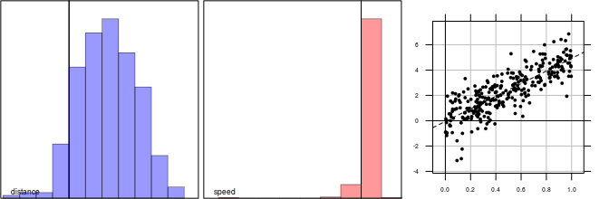

```r
plot(tra1)
```

Graphical parameters can be modified by:

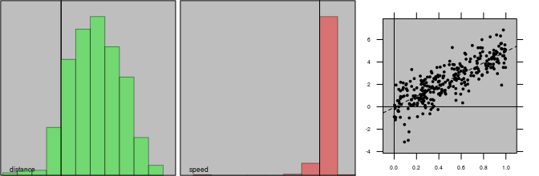

```r
plot(tra1, histDist.ppoly.col = "green", pbackground.col = "grey")
```

# 6 Examples

## 6.1 Labels customization

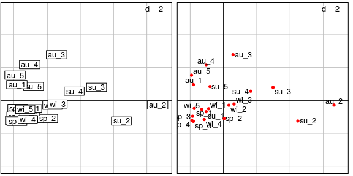

```r
data(meaudret)
g16 <- s.label(pca3$li, plot = FALSE)
g17 <- s.label(pca3$li, ppoints.col= "red", plabels = list(box = list(draw = FALSE),
  optim = TRUE), plot = FALSE)
ADEgS(c(g16, g17), layout = c(1, 2))
```

## 6.2 Ellipses, stars and convex hulls

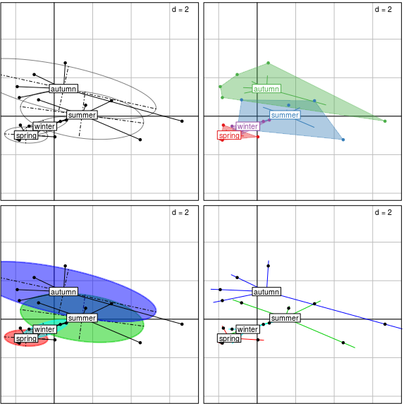

```r
g18 <- s.class(pca3$li, fac = meaudret$design$season, plot = FALSE)
g19 <- s.class(pca3$li, fac = meaudret$design$season, ellipseSize = 0,
  chullSize = 1, starSize = 0.5, col = TRUE, plot = FALSE)
g20 <- s.class(pca3$li, fac = meaudret$design$season, pellipses.lwd = 2,
  pellipses.border = 2:5, pellipses.col = 2:5, plot = FALSE)
g21 <- s.class(pca3$li, fac = meaudret$design$season, ellipseSize = 0,
  chullSize = 0, ppolygons.lwd = 2, plines.col = 2:5, starSize = 1.2, plot = FALSE)
ADEgS(c(g18, g19, g20, g21), layout = c(2, 2))
```

## 6.3 Values and legend

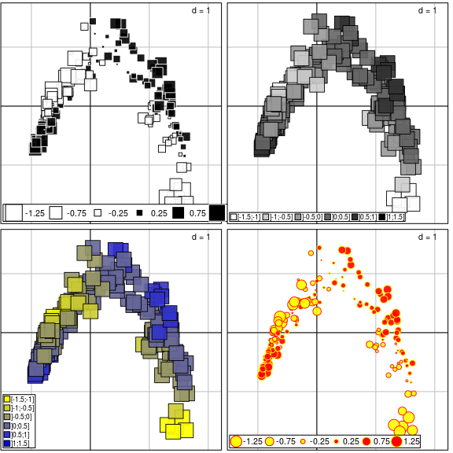

```r
data(rpjdl)
coa2 <- dudi.coa(rpjdl$fau, scannf = FALSE, nf = 3)
g22 <- s.value(coa2$li, coa2$li[,3], plot = FALSE)
g23 <- s.value(coa2$li, coa2$li[,3], method = "color", ppoints.cex = 0.8,
  plegend.size= 0.8, plot = FALSE)
g24 <- s.value(coa2$li, coa2$li[,3], plegend.size = 0.8, ppoints.cex = 0.8,
  symbol = "square", method = "color", key = list(columns = 1),
  col = colorRampPalette(c("yellow", "blue"))(6), plot = FALSE)
g25 <- s.value(coa2$li, coa2$li[, 3], center = 0, method = "size", ppoints.cex = 0.6,
  symbol = "circle", col = c("yellow", "red"), plot = FALSE)
ADEgS(c(g22, g23, g24, g25), layout = c(2, 2))
```

## 6.4 1-D plot

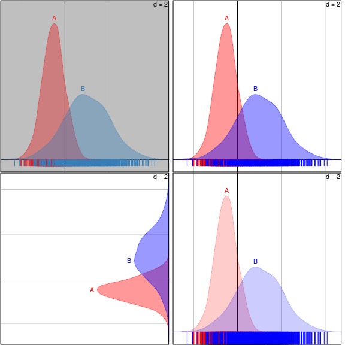

```r
score1 <- c(rnorm(1000, mean = -0.5, sd = 0.5), rnorm(1000, mean = 1))
fac1 <- rep(c("A", "B"), each = 1000)
g26 <- s1d.density(score1, fac1, pback.col = "grey75", plot = FALSE)
g27 <- s1d.density(score1, fac1, col = c(2, 4), plot = FALSE)
g28 <- s1d.density(score1, fac1, col = c(2, 4), p1d.reverse = TRUE, p1d.horizontal = FALSE,
  p1d.rug.draw = FALSE, plot = FALSE)
g29 <- s1d.density(score1, fac1, col = c(2, 4), ppolygons.alpha = 0.2,
  p1d = list(rug = list(tck = 1, line = FALSE)), plot = FALSE)
ADEgS(c(g26, g27, g28, g29), layout = c(2, 2))
```

## 6.5 Maps and neighbor graphs

[figure not shown]

```r
library(Guerry)
library(sp)
data(gfrance85)
region.names <- data.frame(gfrance85)[, 5]
col.region <- colors()[c(149, 254, 468, 552, 26)]
g30 <- s.class(coordinates(gfrance85), region.names, porigin.include = FALSE, plot = FALSE)
g31 <- s.class(coordinates(gfrance85), region.names, ellipseSize = 0, starSize = 0,
  Sp = gfrance85, pgrid.draw = FALSE, pSp.col = col.region[region.names], pSp.alpha = 0.4,
  plot = FALSE)
ADEgS(c(g30, g31), layout = c(1, 2))
```

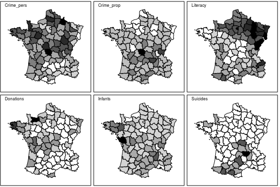

```r
s.Spatial(gfrance85[,7:12])
```

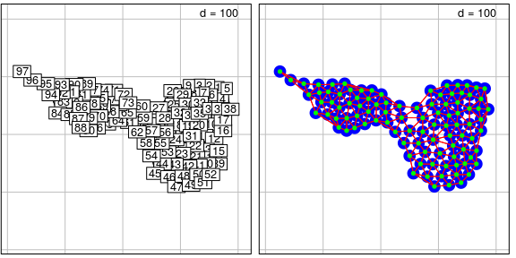

```r
data(mafragh, package = "ade4")
g32 <- s.label(mafragh$xy, nb = mafragh$nb, plot = FALSE)
g33 <- s.label(mafragh$xy, nb = mafragh$nb, pnb.ed.col = "red", plab.cex = 0,
  pnb.node = list(cex = 3, col = "blue"), ppoints.col = "green", plot = FALSE)
ADEgS(c(g32, g33), layout = c(1, 2))
```

## 6.6 Ternary plots

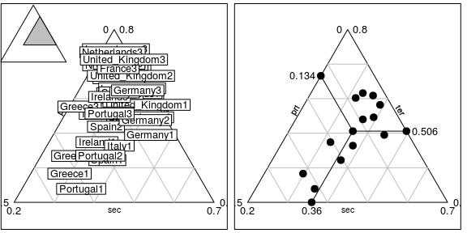

```r
data(euro123, package = "ade4")
df <- rbind.data.frame(euro123$in78, euro123$in86, euro123$in97)
row.names(df) <- paste(row.names(euro123$in78), rep(c(1, 2, 3), rep(12, 3)), sep = "")
g34 <- triangle.label(df, label = row.names(df), showposition = TRUE, plot = FALSE)
g35 <- triangle.label(euro123$in78, plabels.cex = 0, ppoints.cex = 2, addmean = TRUE,
  show = FALSE, plot = FALSE)
ADEgS(c(g34, g35), layout = c(1, 2))
```

# 7 Appendix

This appendix summarizes the main changes between `ade4` and `adegraphics`. Each line corresponds to a graphical argument defined in `ade4` and its equivalent in `adegraphics` is given.

| Arguments in `ade4` | Functions in `ade4` | `g.args` in `adegraphics` | `adeg.par` in `adegraphics` |  |
| --- | --- | --- | --- | --- |
| `abline.x` | `table.cont` | `ablineX` |  |  |
| `abline.y` | `table.cont` | `ablineY` |  |  |
| `abmean.x` | `table.cont` | `meanX` |  |  |
| `abmean.y` | `table.cont` | `meanY` |  |  |
| `addaxes` | `s.arrow`, `s.chull`, `s.class`, `s.distri`, `s.image`, `s.kde2d`, `s.label`, `s.logo`, `s.match`, `s.traject`, `s.value`, `triangle.class`, `triangle.plot` |  | `paxes.draw` |  |
| `area` | `s.arrow`, `s.chull`, `s.class`, `s.distri`, `s.image`, `s.kde2d`, `s.label`, `s.logo`, `s.match`, `s.traject`, `s.value` | `Sp` |  | a `Sp` object |
| `axesell` | `s.class`, `s.distri`, `triangle.class` |  | `pellipses.axes.draw` |  |
| `box` | `s.corcircle`, `triangle.plot` |  | `pbackground.box` |  |
| `boxes` | `s.arrow`, `s.label`, `sco.class`, `sco.label`, `sco.match` |  | `plabels.boxes.draw` |  |
| `cellipse` | `s.class`, `s.distri`, `triangle.class` | `ellipseSize` |  |  |
| `cgrid` | `s.arrow`, `s.class`, `s.chull`, `s.corcircle`, `s.distri`, `s.image`, `s.kde2d`, `s.label`, `s.logo`, `s.match`, `s.traject`, `s.value`, `sco.boxplot`, `sco.class`, `sco.distri`, `sco.gauss`, `sco.la… |  | `pgrid.nint` | both play on the grid mesh, but they are not strictly equivalent |
| `clabel` | `s.arrow`, `s.class`, `s.chull`, `s.corcircle`, `s.distri`, `s.kde2d`, `s.label`, `s.match`, `s.traject`, `sco.boxplot`, `sco.class`, `sco.distri`, `sco.gauss`, `sco.label`, `sco.match`, `triangle.plo… |  | `plabels.cex` |  |
| `clabel` | `table.dist` |  |  | `axis.text = list()` `lattice` parameter |
| `clabel.col` | `table.cont`, `table.paint`, `table.value` |  |  | `axis.text = list()` `lattice` parameter |
| `clabel.row` | `table.cont`, `table.paint`, `table.value` |  |  | `axis.text = list()` `lattice` parameter |
| `clegend` | `s.value`, `table.cont`, `table.value` |  | `plegend.size` `ppoints.cex` | parameters setting the legend size |
| `clegend` | `table.paint` |  | `plegend.size` |  |
| `clogo` | `s.logo` |  | `ppoints.cex` |  |
| `cneig` | `s.image`, `s.kde2d`, `s.label`, `s.logo`, `s.value` |  | `pnb.edge.lwd` |  |
| `col.labels` | `table.cont`, `table.paint`, `table.value` | `labelsy` |  |  |
| `contour` | `s.arrow`, `s.class`, `s.chull`, `s.distri`, `s.image`, `s.kde2d`, `s.label`, `s.logo`, `s.match`, `s.traject`, `s.value` | `Sp` |  | a `Sp` object |
| `contour.plot` | `s.image` | `region` |  |  |
| `cpoints`, `cpoint` | `s.arrow`, `s.class`, `s.chull`, `s.distri`, `s.kde2d`, `s.label`, `s.match`, `s.traject`, `s.value`, `sco.class`, `sco.label`, `sco.match`, `triangle.class`, `triangle.plot` |  | `ppoints.cex` |  |
| `csize` | `s.value`, `table.cont`, `table.dist`, `table.paint`, `table.value` | `ppoints.cex` |  |  |
| `csize` | `sco.distri` | `sdSize` |  |  |
| `cstar` | `s.class`, `s.distri`, `triangle.class` | `starSize` |  |  |
| `csub` | `s.arrow`, `s.chull`, `s.class`, `s.corcircle`, `s.distri`, `s.image`, `s.kde2d`, `s.label`, `s.logo`, `s.match`, `s.traject`, `s.value`, `sco.boxplot`, `sco.class`, `sco.distri`, `sco.gauss`, `sco.la… |  | `psub.cex` |  |
| `draw.line` | `triangle.biplot`, `triangle.class`, `triangle.plot` |  | `pgrid.draw` |  |
| `edge` | `s.arrow`, `s.match`, `s.traject` |  | `parrows.length` | setting the length of the arrows to 0 is equivalent to `edge = FALSE` |
| `grid` | `s.arrow`, `s.chull`, `s.class`, `s.corcircle`, `s.distri`, `s.image`, `s.kde2d`, `s.label`, `s.logo`, `s.match`, `s.traject`, `s.value`, `sco.boxplot`, `sco.class`, `sco.distri`, `sco.gauss`, `sco.la… |  | `pgrid.draw` |  |
| `horizontal` | `sco.class`, `sco.gauss`, `sco.label`, `sco.match` |  | `p1d.horizontal` |  |
| `image.plot` | `s.image` | `contour` |  |  |
| `includeorigin`, `include.origin` | `s.arrow`, `s.chull`, `s.class`, `s.distri`, `s.image`, `s.kde2d`, `s.label`, `s.logo`, `s.match`, `s.traject`, `s.value`, `sco.boxplot`, `sco.class`, `sco.distri`, `sco.gauss`, `sco.label`, `sco.matc… |  | `porigin.include` |  |
| `kgrid` | `s.image` | `gridsize` |  |  |
| `klogo` | `s.logo` |  |  | no correspondence |
| `labeltriangle` | `triangle.class` , `triangle.plot` |  |  | no correspondence |
| `legen` | `sco.gauss` | `labelplot` |  |  |
| `neig` | `s.image`, `s.kde2d`, `s.label`, `s.logo`, `s.value` | `nbobject` |  | a `nb` object |
| `optchull` | `s.chull` | `chullSize` |  |  |
| `origin` | `s.arrow`, `s.chull`, `s.class`, `s.corcircle`, `s.distri`, `s.image`, `s.kde2d`, `s.label`, `s.logo`, `s.match`, `s.traject`, `s.value`, `sco.boxplot`, `sco.class`, `sco.distri`, `sco.gauss`, `sco.la… |  | `porigin.origin` |  |
| `pch` | `s.arrow`, `s.chull`, `s.class`, `s.distri`, `s.kde2d`, `s.label`, `s.match`, `s.traject`, `s.value`, `sco.boxplot`, `sco.class`, `sco.label`, `sco.match`, `triangle.class`, `triangle.plot`, `table.co… |  | `ppoints.pch` |  |
| `pixmap` | `s.arrow`, `s.chull`, `s.class`, `s.distri`, `s.image`, `s.kde2d`, `s.label`, `s.logo`, `s.match`, `s.traject`, `s.value` |  |  | no correspondence |
| `pos.lab` | `sco.class`, `sco.label`, `sco.match` |  | `p1d.labpos` |  |
| `possub` | `s.arrow`, `s.chull`, `s.class`, `s.corcircle`, `s.distri`, `s.image`, `s.kde2d`, `s.label`, `s.logo`, `s.match`, `s.traject`, `s.value`, `sco.class`, `sco.gauss`, `sco.label`, `sco.match`, `triangle.… |  | `psub.pos` |  |
| `rectlogo` | `s.logo` | `rect` |  |  |
| `reverse` | `sco.class`, `sco.gauss`, `sco.label`, `sco.match` |  | `p1d.reverse` |  |
| `row.labels` | `table.cont`, `table.paint`, `table.value` | `labelsx` |  |  |
| `scale` | `triangle.class`, `triangle.plot` | `adjust` |  |  |
| `show.position` | `triangle.class`, `triangle.plot` | `showposition` |  |  |
| `sub` | `s.arrow`, `s.chull`, `s.class`, `s.corcircle`, `s.distri`, `s.image`, `s.kde2d`, `s.label`, `s.logo`, `s.match`, `s.traject`, `s.value`, `sco.boxplot`, `sco.class`, `sco.distri`, `sco.gauss`, `sco.la… |  | `psub.text` |  |
| `y.rank` | `sco.distri` | `yrank` |  |  |
| `zmax` | `s.value` |  |  | set to default max(abs(z)) |

# References

Dray, S., and A. B. Dufour. 2007. “The Ade4 Package: Implementing the Duality Diagram for Ecologists.” *Journal of Statistical Software* 22 (4): 1–20.

Murrell, P. 2005. *R Graphics*. Chapman & Hall/CRC.

Sarkar, D. 2008. *Lattice: Multivariate Data Visualization with R*. Springer.

[^1]: The `table.value` function is now generic and can handle `dist` or `table` objects as arguments.
[^2]: Convex hulls are now drawn by the `s.class` function (argument `chullSize`.)